# Honors Assignment: Creating interactive ggplots

2023-01-01

# 1 Intro

Welcome!

For this assignment, you will need to create a ggplot graph and add interactivity to it using the **{plotly}** package. https://plotly.com/ggplot2/.

The final due date for the assignment is Tuesday, January 31th at 23:59 PM UTC+2.

# 2 Getting started

Let’s begin by loading the packages you will need to use:

```r
# Load packages
if(!require(pacman)) install.packages("pacman")
```

```r
pacman::p_load(plotly, # for adding interactivity!
               tidyverse, # for ggplot2 and dplyr
               htmlwidgets, # for saving interactive graph
               gapminder, # for data
               RColorBrewer # for nice color palettes
               )
```

We have not yet used {plotly} or {RColorBrewer} in this course. This code will install these packages if you don’t have them already.

Next, we will load in and prepare data that I will use to demonstrate for to make an interactive plot with ggplot2 and plotly.

In this lesson, we will be using the `gapminder` dataset, but only the data from 2007.

```r
# Import data frame from gapminder package
gapminder07 <- gapminder::gapminder %>%
  # filter data frame to only include data from 2007
  filter(year == 2007) %>%
  # remove the year column
  select(-year) %>%
  # rename columns to make them easier to understand
  rename(life_expectancy = lifeExp,
         population = pop,
         gdp_per_capita = gdpPercap) %>%
  # reorder dataset by population size (this is important for plotting)
  arrange(desc(population))
```

```r
# View dataset
head(gapminder07, 10)
```

```
## # A tibble: 10 × 5
##    country       continent life_expectancy population gdp_per_capita
##    <fct>         <fct>               <dbl>      <int>          <dbl>
##  1 China         Asia                 73.0 1318683096          4959.
##  2 India         Asia                 64.7 1110396331          2452.
##  3 United States Americas             78.2  301139947         42952.
##  4 Indonesia     Asia                 70.6  223547000          3541.
##  5 Brazil        Americas             72.4  190010647          9066.
##  6 Pakistan      Asia                 65.5  169270617          2606.
##  7 Bangladesh    Asia                 64.1  150448339          1391.
##  8 Nigeria       Africa               46.9  135031164          2014.
##  9 Japan         Asia                 82.6  127467972         31656.
## 10 Mexico        Americas             76.2  108700891         11978.
```

# 3 Intro to plotly

The **plotly** package is used to create interactive graphs in R and Python. It can used to make a variety of plot types, just like ggplot.

An interactive chart allows you to change what the chart shows by taking actions: pan and zoom, hover over a geom to get additional information, choose which variables to display, and more.

Let’s say we want to view the relationship between life expectancy and GPD per capita in `gapminder07`

Here’s how we would do this with ggplot:

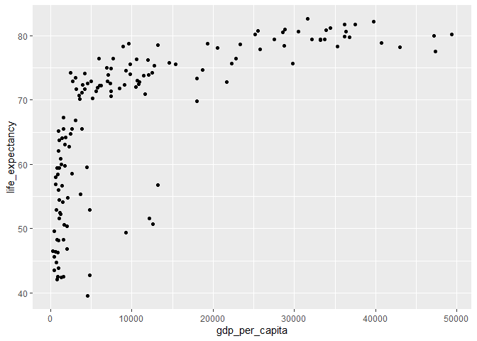

```r
# Simple scatter plot using ggplot2
ggplot(data = gapminder07,
       mapping = aes(x = gdp_per_capita,
                     y = life_expectancy)) +
  geom_point()
```

You *could* learn plotly syntax use the `plot_ly()` function to do this in one step (but we will not be using this method):

```r
# Interactive scatter plot using plot_ly!
plot_ly(data = gapminder07,
        x = ~gdp_per_capita,
        y = ~life_expectancy)
```

[interactive chart not shown]

You can hover over the points to see raw data values.

But we don’t need to do this and learn all that syntax, instead we will use the `ggplotly()` function that makes this super easy!

**`ggplotly()`** is a function converts ggplot objects into interactive plots in two simple steps:

1. Create a named ggplot2 plot using the **`ggplot()`** function and the assignment operator (`<-`).
2. Use the **`ggplotly()`** function to convert the ggplot2 plot into an interactive plotly plot: **`ggplotly(PLOT_NAME)`**

**Step 1**

```r
# First create ggplot object
base_ggplot <-
  ggplot(data = gapminder07,
         mapping = aes(x = gdp_per_capita,
                       y = life_expectancy)) +
  geom_point()
```

**Step 2**

```r
# Transform plot with ggplotly()
ggplotly(base_ggplot)
```

[interactive chart not shown]

## 3.1 labels

we can add country labels to hover text using the labels aesthetic.

```r
# Create a ggplot2 plot with data labels for the country variable

gapminder_plot <- ggplot(
  data = gapminder07,
  mapping = aes(
    x = gdp_per_capita,
    y = life_expectancy,
    label = country)) +
  geom_point()

# Convert the ggplot2 plot to an interactive plotly plot

ggplotly(gapminder_plot)
```

[interactive chart not shown]

## 3.2 export/save

html widget

```r
# Create widget
gapminder_plotly <- ggplotly(gapminder_plot)

#htmlwidgets::saveWidget(as_widget(gapminder_plotly),  "ggplot_honors/interactive_ggplotly/lifeExp_GDP_07_widget.html")
```

# 4 Requirements

- use at least 3 aesthetic mappings
- at least one fixed aesthetic
- edit scale or position
- use the `labs()` function

# 5 Submission: Upload zipped folder

The final due date for the assignment is Tuesday, January 31th at 23:59 PM UTC+2.